# Intro to `ggplot2`

Jake Rozran

2022-02-02

# The Data We’ll Use for Class Today

```r
data("CIACountries") # GIMME THE DATA

?CIACountries # WHAT IS THIS DATA?

head(CIACountries) # SHOW ME THE DATA
```

```
##          country      pop    area oil_prod   gdp educ   roadways net_users
## 1    Afghanistan 32564342  652230        0  1900   NA 0.06462444       >5%
## 2        Albania  3029278   28748    20510 11900  3.3 0.62613051      >35%
## 3        Algeria 39542166 2381741  1420000 14500  4.3 0.04771929      >15%
## 4 American Samoa    54343     199        0 13000   NA 1.21105528      <NA>
## 5        Andorra    85580     468       NA 37200   NA 0.68376068      >60%
## 6         Angola 19625353 1246700  1742000  7300  3.5 0.04125211      >15%
```

```r
str(CIACountries) # SHOW ME THE DATA DIFFERENTLY
```

```
## 'data.frame':    236 obs. of  8 variables:
##  $ country  : chr  "Afghanistan" "Albania" "Algeria" "American Samoa" ...
##  $ pop      : num  32564342 3029278 39542166 54343 85580 ...
##  $ area     : num  652230 28748 2381741 199 468 ...
##  $ oil_prod : num  0 20510 1420000 0 NA ...
##  $ gdp      : num  1900 11900 14500 13000 37200 7300 12200 23600 22600 8500 ...
##  $ educ     : num  NA 3.3 4.3 NA NA 3.5 2.8 2.4 6.3 3.3 ...
##  $ roadways : num  0.0646 0.6261 0.0477 1.2111 0.6838 ...
##  $ net_users: Factor w/ 5 levels ">0%",">5%",">15%",..: 2 4 3 NA 5 3 3 5 4 4 ...
```

```r
summary(CIACountries) # SUMMARIZE THE DATA FOR ME
```

```
##    country               pop                  area             oil_prod
##  Length:236         Min.   :        48   Min.   :       0   Min.   :       0
##  Class :character   1st Qu.:    343506   1st Qu.:    2498   1st Qu.:       0
##  Mode  :character   Median :   5311480   Median :   73580   Median :       0
##                     Mean   :  30747852   Mean   :  577876   Mean   :  373125
##                     3rd Qu.:  18350763   3rd Qu.:  414643   3rd Qu.:   51130
##                     Max.   :1367485388   Max.   :17098242   Max.   :10840000
##                                                             NA's   :23
##       gdp              educ           roadways        net_users
##  Min.   :   400   Min.   : 0.600   Min.   : 0.00639   >0% :24
##  1st Qu.:  4775   1st Qu.: 3.300   1st Qu.: 0.12239   >5% :30
##  Median : 13750   Median : 4.700   Median : 0.33474   >15%:36
##  Mean   : 21398   Mean   : 4.855   Mean   : 1.10849   >35%:59
##  3rd Qu.: 31650   3rd Qu.: 5.900   3rd Qu.: 1.15395   >60%:67
##  Max.   :132100   Max.   :13.000   Max.   :38.50000   NA's:20
##  NA's   :8        NA's   :63       NA's   :13
```

```r
unique(CIACountries$country) # WHAT COUNTRIES ARE HERE?
```

```
##   [1] "Afghanistan"
##   [2] "Albania"
##   [3] "Algeria"
##   [4] "American Samoa"
##   [5] "Andorra"
##   [6] "Angola"
##   [7] "Anguilla"
##   [8] "Antigua and Barbuda"
##   [9] "Argentina"
##  [10] "Armenia"
##  [11] "Aruba"
##  [12] "Australia"
##  [13] "Austria"
##  [14] "Azerbaijan"
##  [15] "Bahamas, The"
```

[output cut: 221 more lines]

# The `ggplot` object

- `ggplot2` is a library to build data graphics
- The reason that `ggplot2` has been so successful is that it allows you to build graphics incrementally
- The first thing we do is create a `ggplot` object
- There are two methods for doing this (I prefer the second, as it makes it clearer at a glance what all the aesthetics and layers are)

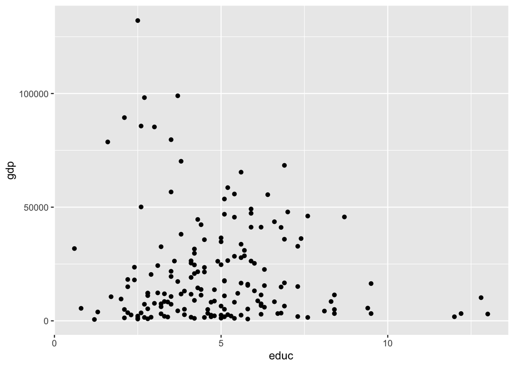

```r
# Book Method - Assign a variable the ggplot object
# Then use that variable to build upon
g <- ggplot(data = CIACountries, aes(x = educ, y = gdp))
g + geom_point()
```

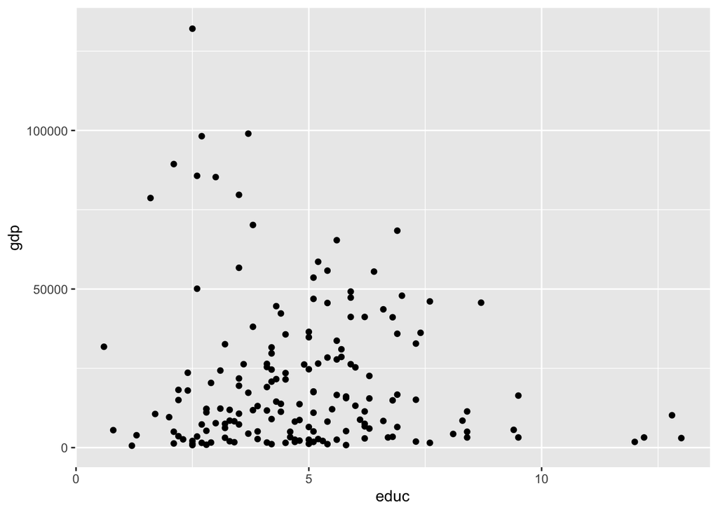

```r
# I prefer to keep the object unassigned so I can see all the parts
# This becomes especially useful as you build your graphics over huge scripts
ggplot(data = CIACountries, aes(x = educ, y = gdp)) +
    geom_point()
```

## What are we Looking at Here?

1. The `ggplot` object
   - This informs which data to use - in this case `CIACountries` and then which aethestics to use with the `aes()` function
   - Here, we are telling `ggplot` to use the `educ` column for the `x` position and `gdp` for the `y` position
2. The `geom_point()` layer
   - This is the “glyph” we want to plot
   - Each point is a different country, located at its `educ` and `gdp`
   - *Note:* the size for each point is the same, so it is not an aesthetic (it does not map to a visual cue)

## Adding More Visual Cues

- You can add additional aesthetics beyond `x` and `y`.
- You can add them in the `ggplot` object (if they will be used universally) OR
- You can add them in the layer object

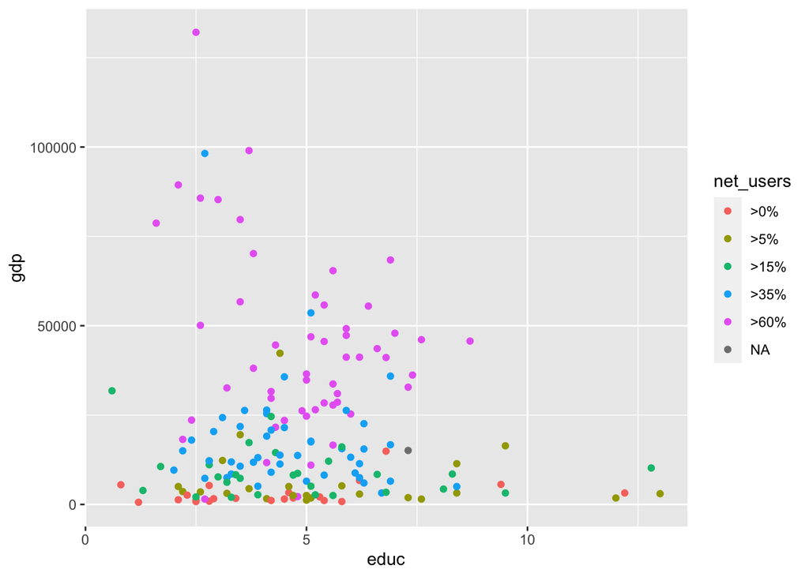

```r
ggplot(data = CIACountries, aes(x = educ, y = gdp)) +
    geom_point(aes(color = net_users))
```

### To Change an Aestetic or Not, That is the Question

You can also customize a layer universally (not based on a variable in the data)

In the code below, we change the size of the dot to be bigger for all dots (still not a visual cue, but does make the plot easier to read).

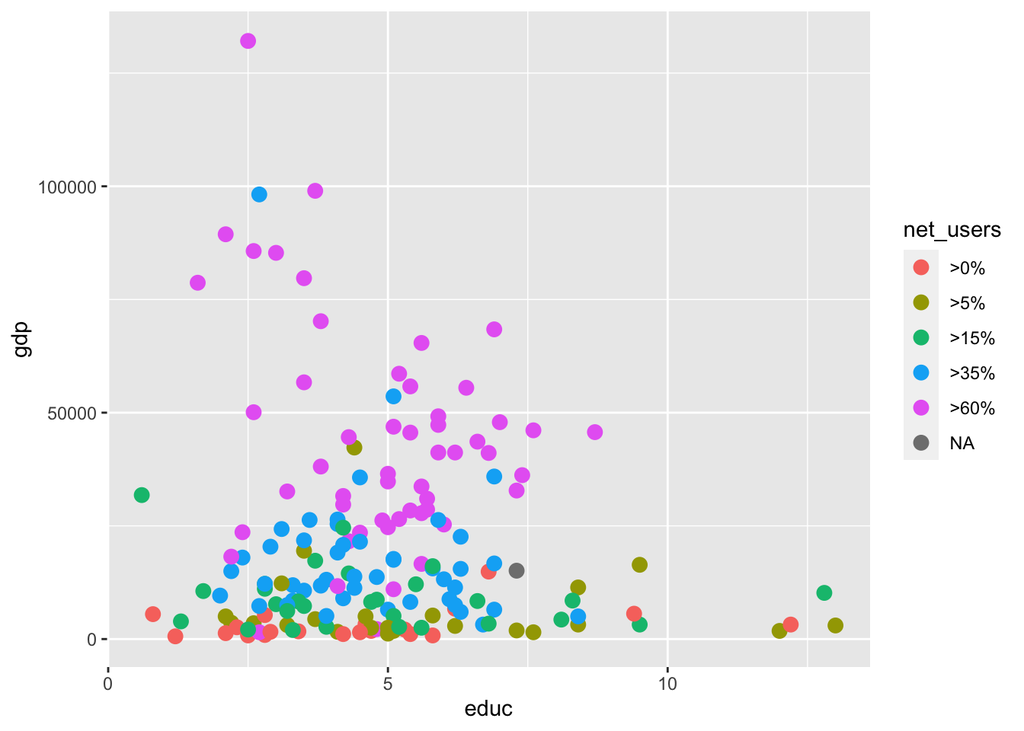

```r
ggplot(data = CIACountries, aes(x = educ, y = gdp)) +
    geom_point(aes(color = net_users), size = 3)
```

We can, however, also make size an aesthetic (and add even more information to the plot)!

*Note: There is a such a thing as too much information in a plot… be careful* *not to add too many aesthetics.*

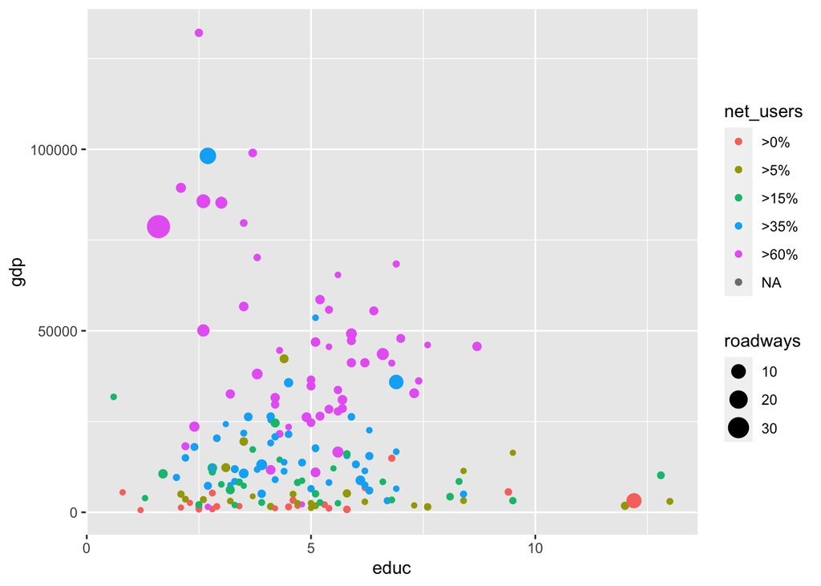

```r
ggplot(data = CIACountries, aes(x = educ, y = gdp)) +
    geom_point(aes(color = net_users, size = roadways))
```

### Let’s get Wild - there is a World of Things to Change

- All of these “features” can be assigned via `aes()` or not (which makes them universal changes)
- `alpha` is the one that may seem less intuitive, it is the opacity (between 0 and 1)
- `color` (or `colour`, if you prefer) is the color of lines
- `fill` is the color filling an object (like a bar or the squares below)
- There are a bunch of shapes built in ([I googled it and there is a list](https://www.datanovia.com/en/blog/ggplot-point-shapes-best-tips/))

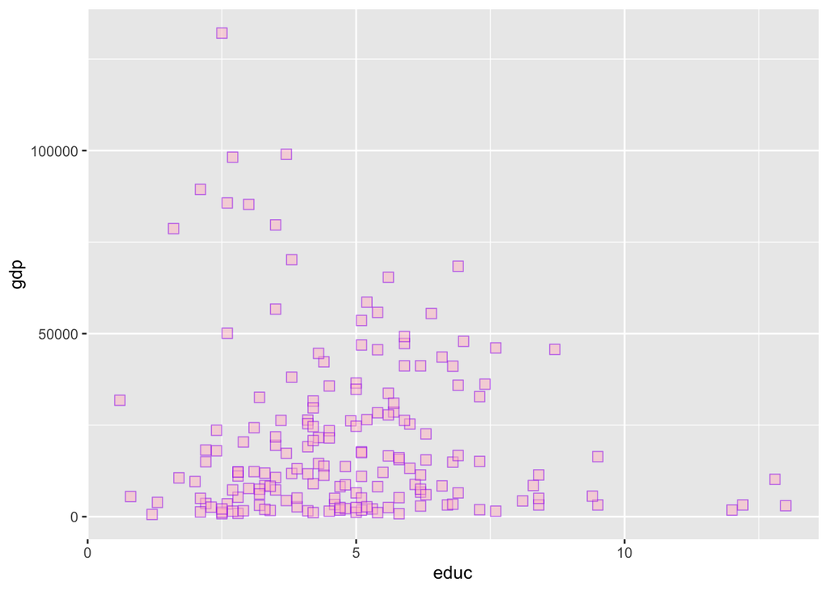

```r
ggplot(data = CIACountries, aes(x = educ, y = gdp)) +
    geom_point(size = 3,
               color = "purple",
               alpha = 0.5,
               shape = 22,
               fill = "pink")
```

### Going Beyond Points

- Obviously there are more than just scatter plots in this world
- You can build any plot you can imagine with `ggplot2` (I may not have a great imagination)
- Check out the `ggplot2` cheat sheet on the [RStudio Website](https://www.rstudio.com/resources/cheatsheets/) or our [Google Drive](https://drive.google.com/drive/u/2/folders/1UDfF9IGHay82mZo97NBvgkKoEjSIfP39)

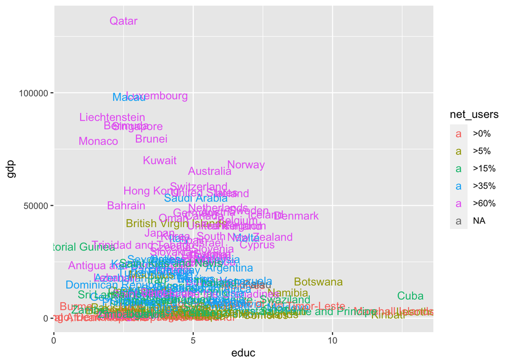

```r
ggplot(data = CIACountries, aes(x = educ, y = gdp)) +
    geom_text(aes(label = country, color = net_users))
```

### The Beat and the Chorus at the SAME TIME!

We’re not really ready for this yet, but we can add multiple layers, too!

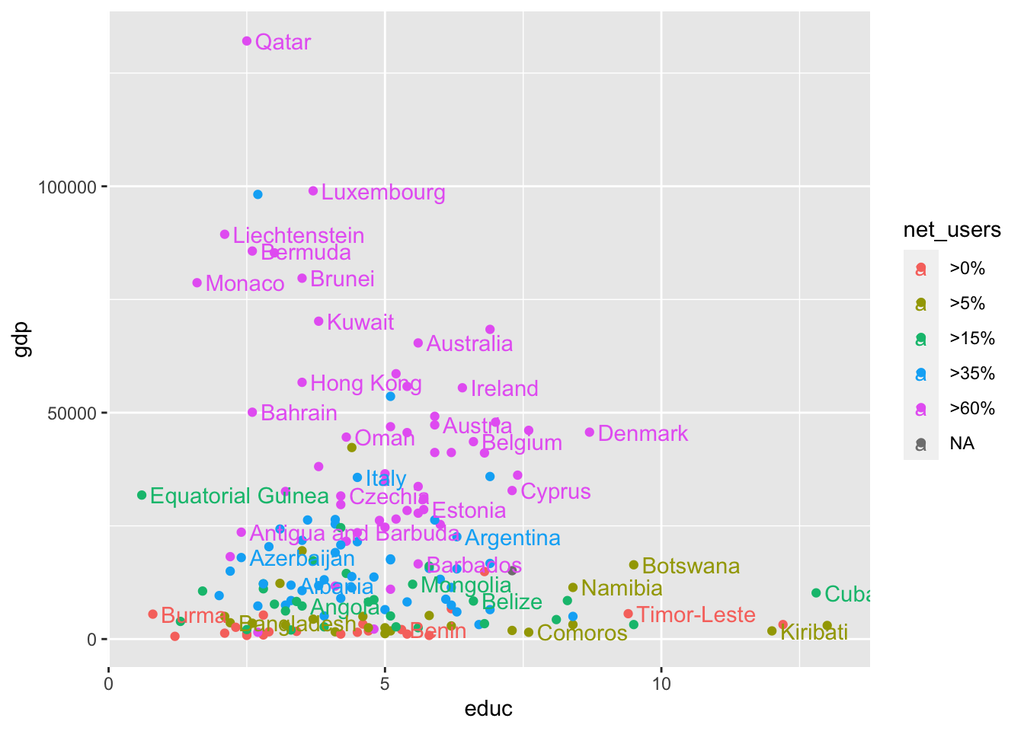

```r
ggplot(data = CIACountries, aes(x = educ, y = gdp, color = net_users)) +
    geom_point() +
    geom_text(aes(label = country),
              nudge_x = 0.15,
              check_overlap = TRUE,
              hjust = 0)
```